# Reproducible Research: Peer Assessment 2

Author: Matthew Bender July 25th 2015

## The effects of weather events on the United States public heath and economically

### Synopsis

The goal of this data analysis is to determine the more impactful types of weather on the United States human population and economically between 1950-2011. I used injuries and fatalities to classify weather events that affected population health most. I used property and crop damage to determine which weather events were most economically impactful.

### Data Processing

The storm data is downloadable [Here](https://d396qusza40orc.cloudfront.net/repdata%2Fdata%2FStormData.csv.bz2) [47Mb] and unzipped with bunzip2.

#### Basic Setup

```r
echo=TRUE # Echo all code segments
options(scipen = 12)
library(R.utils)
```

```r
library(ggplot2)
library(tidyr)
library(dplyr)
```

#### Downloand & unzip file

```r
if(!file.exists('stormData.csv')) {
  download.file("https://d396qusza40orc.cloudfront.net/repdata%2Fdata%2FStormData.csv.bz2", destfile = "stormData.csv.bz2", method = 'curl')
  bunzip2("stormData.csv.bz2")
}
```

#### Load data

```r
stormData <- read.csv('stormData.csv', stringsAsFactors = FALSE)
dim(stormData)
```

```
## [1] 902297     37
```

```r
names(stormData)
```

```
##  [1] "STATE__"    "BGN_DATE"   "BGN_TIME"   "TIME_ZONE"  "COUNTY"
##  [6] "COUNTYNAME" "STATE"      "EVTYPE"     "BGN_RANGE"  "BGN_AZI"
## [11] "BGN_LOCATI" "END_DATE"   "END_TIME"   "COUNTY_END" "COUNTYENDN"
## [16] "END_RANGE"  "END_AZI"    "END_LOCATI" "LENGTH"     "WIDTH"
## [21] "F"          "MAG"        "FATALITIES" "INJURIES"   "PROPDMG"
## [26] "PROPDMGEXP" "CROPDMG"    "CROPDMGEXP" "WFO"        "STATEOFFIC"
## [31] "ZONENAMES"  "LATITUDE"   "LONGITUDE"  "LATITUDE_E" "LONGITUDE_"
## [36] "REMARKS"    "REFNUM"
```

#### Drop unused columns

```r
importantCols <- c("EVTYPE", "INJURIES", "FATALITIES", "PROPDMG", "PROPDMGEXP",
                   "CROPDMG", "CROPDMGEXP")
stormData <- stormData[importantCols]
dim(stormData)
```

```
## [1] 902297      7
```

#### Convert damage amounts into dollars

```r
convertMagnitude <- function(x) {
  if (x == '') {
    return(0)
  }

  switch(toupper(x),
          '?' = 0,
          '-' = NA,
          '+' = NA,
          'H' = 2,
          'K' = 3,
          'M' = 6,
          'B' = 9,
          x)
}

stormData$PROPDMGEXP <- sapply(as.character(stormData$PROPDMGEXP),
                               convertMagnitude)
stormData$PROPDMGEXP <- as.numeric(stormData$PROPDMGEXP)

stormData$PROPDMG <- stormData$PROPDMG * 10^stormData$PROPDMGEXP

stormData$CROPDMGEXP <- sapply(as.character(stormData$CROPDMGEXP),
                               convertMagnitude)
stormData$CROPDMGEXP <- as.numeric(stormData$CROPDMGEXP)

stormData$CROPDMG <- stormData$CROPDMG * 10^stormData$CROPDMGEXP


stormData$PROPDMGEXP <- NULL
stormData$CROPDMGEXP <- NULL


summary(stormData)
```

```
##     EVTYPE             INJURIES           FATALITIES
##  Length:902297      Min.   :   0.0000   Min.   :  0.0000
##  Class :character   1st Qu.:   0.0000   1st Qu.:  0.0000
##  Mode  :character   Median :   0.0000   Median :  0.0000
##                     Mean   :   0.1557   Mean   :  0.0168
##                     3rd Qu.:   0.0000   3rd Qu.:  0.0000
##                     Max.   :1700.0000   Max.   :583.0000
##
##     PROPDMG                CROPDMG
##  Min.   :           0   Min.   :         0
##  1st Qu.:           0   1st Qu.:         0
##  Median :           0   Median :         0
##  Mean   :      474597   Mean   :     54421
##  3rd Qu.:         500   3rd Qu.:         0
##  Max.   :115000000000   Max.   :5000000000
##  NA's   :6
```

#### Group weather event types

There are many duplicated weather event types in the data, so I grouped similar types of events and cleaned up type names.

```r
eventTypes <- levels(factor(stormData$EVTYPE))
length(eventTypes)
```

```
## [1] 985
```

```r
stormData[grep('cold|freez|ice|winter|blizzard|snow|wintry|icy',
               stormData$EVTYPE,
               ignore.case=TRUE),]$EVTYPE = 'COLD WEATHER'
stormData[grep('heat|hot|warm|dry', stormData$EVTYPE,
               ignore.case=TRUE),]$EVTYPE = 'HEAT'
stormData[grep('wind|wnd', stormData$EVTYPE,
               ignore.case = TRUE),]$EVTYPE = 'WIND'
stormData[grep('tornado|waterspout|funnel', stormData$EVTYPE,
               ignore.case = TRUE),]$EVTYPE = 'TORNADO'
stormData[grep('flooding|flood|rain|wet', stormData$EVTYPE,
               ignore.case=TRUE),]$EVTYPE = 'FLOODING'
stormData[grep('dry|drought', stormData$EVTYPE,
               ignore.case=TRUE),]$EVTYPE = 'DROUGHT'
stormData[grep('fire', stormData$EVTYPE,
               ignore.case=TRUE),]$EVTYPE = 'WILD FIRE'
stormData[grep('hurricane|typhoon|surge', stormData$EVTYPE,
               ignore.case=TRUE),]$EVTYPE = 'HURRICANE'
stormData[grep('tropical', stormData$EVTYPE,
               ignore.case=TRUE),]$EVTYPE = 'TROPICAL STORM'
stormData[grep('surf|current|wave', stormData$EVTYPE,
               ignore.case=TRUE),]$EVTYPE = 'SURF'
stormData[grep('lightning', stormData$EVTYPE,
               ignore.case=TRUE),]$EVTYPE = 'LIGHTNING'
stormData[grep('hail', stormData$EVTYPE,
               ignore.case=TRUE),]$EVTYPE = 'HAIL'
eventTypes <- levels(factor(stormData$EVTYPE))
length(eventTypes)
```

```
## [1] 238
```

### Data Analysis

I group the data by weather event types, sum the classifiers (FATALITIES, INJURIES) & (PROPDMG, CROPDMG), and sum the sum of the classifiers which created a total impact for the weather type. I then order the weather types by their total impact descending.

#### Determine the most impactful storm events on the human population

```r
healthImpactData <- group_by(stormData, EVTYPE) %>%
    summarize(Deaths=sum(FATALITIES), Injuries=sum(INJURIES),
              Total=sum(INJURIES)+sum(FATALITIES)) %>%
    gather(Impact, ImpactTotal, -EVTYPE, -Total) %>%
    arrange(desc(Total))
healthImpactData <- healthImpactData[1:20,]
head(healthImpactData, n = 20)
```

```
## Source: local data frame [20 x 4]
##
##          EVTYPE Total   Impact ImpactTotal
## 1       TORNADO 97078   Deaths        5639
## 2       TORNADO 97078 Injuries       91439
## 3          WIND 12623   Deaths        1224
## 4          WIND 12623 Injuries       11399
## 5          HEAT 12453   Deaths        3181
## 6          HEAT 12453 Injuries        9272
## 7      FLOODING 10507   Deaths        1625
## 8      FLOODING 10507 Injuries        8882
## 9  COLD WEATHER  7580   Deaths        1098
## 10 COLD WEATHER  7580 Injuries        6482
## 11    LIGHTNING  6049   Deaths         817
## 12    LIGHTNING  6049 Injuries        5232
## 13    WILD FIRE  1698   Deaths          90
## 14    WILD FIRE  1698 Injuries        1608
## 15    HURRICANE  1533   Deaths         157
## 16    HURRICANE  1533 Injuries        1376
## 17         SURF  1513   Deaths         736
## 18         SURF  1513 Injuries         777
## 19         HAIL  1386   Deaths          15
## 20         HAIL  1386 Injuries        1371
```

#### Determine the storm events with the largest economic impact

```r
economicImpactData <- group_by(stormData, EVTYPE) %>%
    summarize(Property=sum(PROPDMG), Crop=sum(CROPDMG),
              Total=sum(PROPDMG)+sum(CROPDMG)) %>%
    gather(Impact, ImpactTotal, -EVTYPE, -Total) %>%
    arrange(desc(Total))
economicImpactData <- economicImpactData[1:20,]
head(economicImpactData, n = 20)
```

```
## Source: local data frame [20 x 4]
##
##                 EVTYPE        Total   Impact  ImpactTotal
## 1            HURRICANE 138728606810 Property 133221634010
## 2            HURRICANE 138728606810     Crop   5506972800
## 3         COLD WEATHER  21340120911 Property  12712992961
## 4         COLD WEATHER  21340120911     Crop   8627127950
## 5                 HAIL  19023935986 Property  15977048513
## 6                 HAIL  19023935986     Crop   3046887473
## 7              DROUGHT  15018672000 Property   1046106000
## 8              DROUGHT  15018672000     Crop  13972566000
## 9            WILD FIRE   8904910130 Property   8501628500
## 10           WILD FIRE   8904910130     Crop    403281630
## 11      TROPICAL STORM   8411023550 Property   7716127550
## 12      TROPICAL STORM   8411023550     Crop    694896000
## 13 SEVERE THUNDERSTORM   1205560000 Property   1205360000
## 14 SEVERE THUNDERSTORM   1205560000     Crop       200000
## 15           LIGHTNING    942501520 Property    930409430
## 16           LIGHTNING    942501520     Crop     12092090
## 17                HEAT    931552630 Property     27058350
## 18                HEAT    931552630     Crop    904494280
## 19           LANDSLIDE    344613000 Property    324596000
## 20           LANDSLIDE    344613000     Crop     20017000
```

### Results

#### Impact on human population of the United States

The most impactful weather events that affect population health are tornadoes, wind, heat, flooding, cold weather, and lightning. Tornadoes are a by far the leading weather related cause for injuries and death in the United States from 1950-2011.

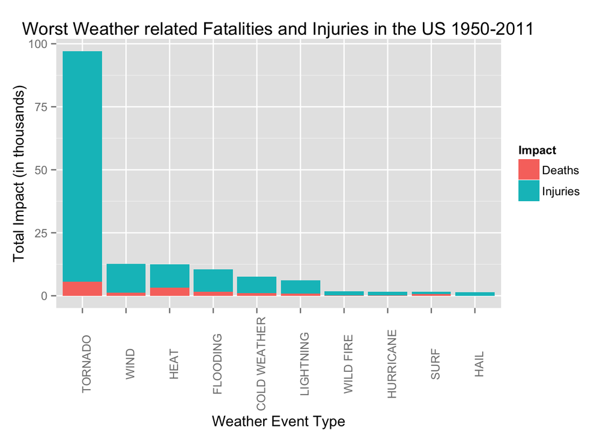

```r
# reorder event types for graph order
eventHealthTypes <- reorder(healthImpactData$EVTYPE, -healthImpactData$Total)

ggplot(healthImpactData, aes(x=eventHealthTypes, y=ImpactTotal/10^3,
                             fill=Impact)) +
  geom_bar(position="stack", stat="identity") +
  theme(axis.text.x=element_text(angle=90)) +
  labs(title = "Worst Weather related Fatalities and Injuries in the US 1950-2011",
       x = "Weather Event Type", y = "Total Impact (in thousands)")
```

#### Greatest economic consequences

The weather events that caused the greatest economic consequences are hurricanes, cold winter weather, hail, drought, wild fires and tropical storms. Hurricanes are the main weather related cause of economic destruction, predominately property damage. The leading cause of crop damage is drought, but barely compares to the total economic impact by hurricanes.

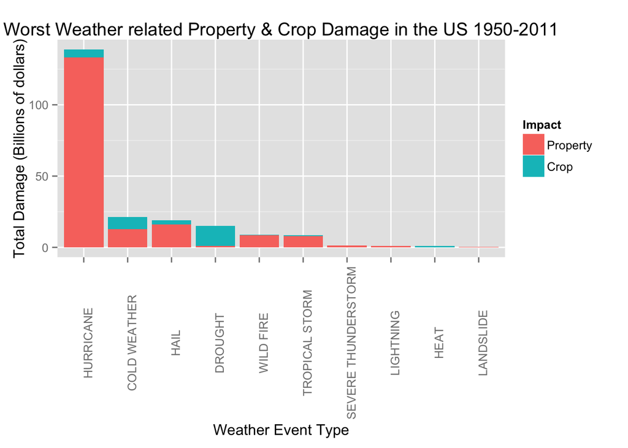

```r
# reorder event types for graph order
eventEconTypes <- reorder(economicImpactData$EVTYPE, -economicImpactData$Total)

ggplot(economicImpactData, aes(x=eventEconTypes, y=ImpactTotal/10^9,
                               fill=Impact)) +
  geom_bar(position="stack", stat="identity") +
  theme(axis.text.x=element_text(angle=90)) +
  labs(title = "Worst Weather related Property & Crop Damage in the US 1950-2011",
       x = "Weather Event Type", y = "Total Damage (Billions of dollars)")
```